# Problem 1: Dark Matter

Authors

Lucca Braudagan

Gabriella Weis

Published

April 28, 2025

In this problem, we have been tasked with investigating dark matter density models and how they affect the resulting rotation curve of orbiting objects. We will be using Python for this problem, so we begin by importing the necessary libraries: pandas to create data frames, numpy for math such as random and infinity, emcee for MCMC modeling, matplotlib and seaborn for graphing, corner for graphing multiple histograms, and the calc_velocity model from models.

```python
import pandas as pd
import numpy as np
import emcee
import matplotlib.pyplot as plt
from matplotlib.lines import Line2D
import seaborn as sbn
import corner
from models import calc_velocity
```

### Part A: Planets

For the first part of this problem, we will be focusing on planets. We begin by setting the random seed to 0 and reading the data from the planets_rot csv to df. We can see that we are given the orbital radius, observed velocity, perihelion distance, aphelion distance, and velocity error for each of the planets in the solar system.

```python
np.random.seed(0)
df = pd.read_csv('data/planets_rot.csv', comment='#')
df
```

|  | name | R_dist | Vobs | perihelion | aphelion | errV |
| --- | --- | --- | --- | --- | --- | --- |
| 0 | Mercury | 5.790000e+07 | 47.9 | 4.600000e+07 | 6.980000e+07 | 3.351472 |
| 1 | Venus | 1.082000e+08 | 35.0 | 1.075000e+08 | 1.089000e+08 | 0.075527 |
| 2 | Earth | 1.496000e+08 | 29.8 | 1.471000e+08 | 1.521000e+08 | 0.165935 |
| 3 | Mars | 2.280000e+08 | 24.1 | 2.067000e+08 | 2.493000e+08 | 0.754598 |
| 4 | Jupiter | 7.785000e+08 | 13.1 | 7.406000e+08 | 8.164000e+08 | 0.212130 |
| 5 | Saturn | 1.432000e+09 | 9.7 | 1.357600e+09 | 1.506500e+09 | 0.167054 |
| 6 | Uranus | 2.867000e+09 | 6.8 | 2.732700e+09 | 3.001400e+09 | 0.106390 |
| 7 | Neptune | 4.515000e+09 | 5.4 | 4.471100e+09 | 4.558900e+09 | 0.017572 |
| 8 | Pluto | 5.906400e+09 | 4.7 | 4.436800e+09 | 7.375900e+09 | 0.405896 |

We know that all of the data values in planets_rot are in km or km/s, but we need them in meters for the rest of the problem. Since we have to convert all of the values, we write a function that converts km to m by multiplying the value by 1000 and returning a list of the converted values.

```python
def km_convert_to_m(not_m):
    in_m = []
    for i in not_m:
        in_m.append(i * 1000)
    return in_m
```

We now use that function to convert all of our values to m or m/s, and we add those back to the original dataframe.

```python
df["R_dist_m"] = km_convert_to_m(df.R_dist)
df["Vobs_m_per_s"] = km_convert_to_m(df.Vobs)
df["perihelion_m"] = km_convert_to_m(df.perihelion)
df["aphelion_m"] = km_convert_to_m(df.aphelion)
df["errV_m_per_s"] = km_convert_to_m(df.errV)
```

We define the density function below. If a given radius value is less than the parameter radius value, the function returns the density. Otherwise, the returned density is 0.

```python
def density(params, distances):
    r0, p0 = params
    return np.where(distances < r0, p0, 0)
```

Next, we will set up our log Prior, Likelihood, and Posterior for Markov Chain Monte Carlo (MCMC) sampling.

Our first function is that of the log Prior. It takes in the term `params`, which will be the $r_0$ and $p_0$, and contains conditions to verify that both are positive. If either is less than 0, the function returns `-Inf`. In other words, that combination is impossible and has zero probability under the Prior. Otherwise, the function returns 0 (1 in log-space), which corresponds to a uniform Prior over the acceptable region.

```python
def ln_prior(params):
    r0, p0 = params
    if r0 < 0 or p0 < 0:
        return -np.inf
    return 0
```

Second is the log Likelihood, which also takes in value `params`. Using the function `calc_velocity()`, which we have imported from models, we can create our `model`. Calc_velocity takes parameter, distance, and density function arguments. In this case, param includes the r0 and p0 values we will provide. Calc_velocity returns a velocity given by $v(r) = \sqrt{\frac{GM_{in}(r)}{r}}$ where $G$ is the gravitational constant, $r$ is the radius, and $M_{in}(r)$ is the total mass within radius r given by the integrated density $\rho(r)$: $M_{in}(r)=\int_{0}^{r}4\pi\rho(r')r'^2dr'$.

Then we calculate the difference between the observed velocities and the predicted velocities from the model and store them in `residuals`. This will help us understand how far off our predictions are from the actual data.

The last piece of the function involves our log Likelihood formula. We break it down into two terms (`term1` and `term2`), but the complete formula is shown below in its entirety.

- $y_i$ = observed data
- $\hat{y_i}$ = model prediction for each $y_i$
- $σ$ = the standard deviation of the error (uncertainty)
- $n$ = number of observations

$$LogL(θ) = -\frac{1}{2σ^2}\sum_{i=1}^n(y_i-\hat{y_i})^2-\frac{n}{2}log(2πσ^2)$$

$$-\frac{1}{2σ^2}\sum_{i=1}^n(y_i-\hat{y_i})^2$$

$$-\frac{n}{2}log(2πσ^2)$$

All of this is implemented into the log Likelihood function below, which returns the sum of `term1` and `term2`.

```python
def ln_likelihood(params):
    model = calc_velocity(params, df.R_dist_m, density)
    residual = df.Vobs_m_per_s - model
    term1 = - 0.5 * np.log(2 * np.pi * df.errV_m_per_s ** 2)
    term2 = - 0.5 * residual ** 2 / df.errV_m_per_s**2
    return sum(term1 + term2)
```

The final log function that we must define is the log Posterior, or probability distribution (which also takes in the `params` value). First, it calls our `ln_prior` function, which returns 0 if both params are valid and `-Inf` if they are not. If it does return `-Inf`, the `ln_pdf` also returns `-Inf`, which means that because the parameter set is invalid, it will have zero probability in the Posterior.

Next, the function computes the Likelihood based on our model’s predictions versus the actual data (using our `ln_likelihood` function) and returns the sum of the Prior and Likelihood calculations. This is the log Posterior, which tells us how probable our parameters are, given the data and our other prior assumptions.

```python
def ln_pdf(params):
    p = ln_prior(params)
    if p == -np.inf:
        return -np.inf
    return p + ln_likelihood(params)
```

Finally, it’s time to create our MCMC chains. We set our starting parameters as $r_0=7\times10^8 m$ and $p_0=1500 kg/m^3$, set the number of walkers to 20, and initialize our sampler using the `EnsembleSampler()` function from `emcee` (which takes in our number of walkers, our number of dimensions, and our log Posterior). Our `starts` are calculated using random.multivariate_normal(), which generates a list of multidimensional values centered around our parameter values and with a covariance matrix based on them as well. Then, we run our sampler using the function `run_mcmc()`, which takes in `starts` and the number of iterations (as well as an optional progress bar). We ran our sampler for 2000 iterations to get an adequate amount of iterations.

```python
params = [7E8, 1500]
num_walkers = 20
sampler = emcee.EnsembleSampler(num_walkers, 2, ln_pdf)
starts = np.random.multivariate_normal(
            mean = params,
            cov = [[(params[0]/100)**2,0],[0,(params[1]/100)**2]],
            size = num_walkers
            )
out = sampler.run_mcmc(starts, 2000, progress=True)
```

To plot the resulting trace plots for our parameters, we can use `matplotlib` and `get_chain()` from `emcee` (which selects all walkers from all chains for the given parameter). We selected 500 iterations (shown in red on the plots below) as the burn-in point, although both parameters seem to diverge over the iterations rather than converge to a value.

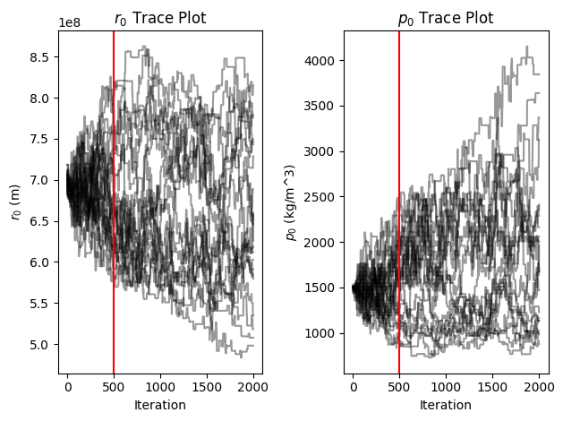

```python
fig, ax = plt.subplots(ncols=2)

ax[0].plot(sampler.get_chain()[:,:,0], 'k', alpha=0.4)
ax[0].axvline(x=500, ymin=0, ymax=1, color='red', label='burn-in point')
ax[0].set_xlabel("Iteration")
ax[0].set_ylabel("$r_0$ (m)")
ax[0].set_title("$r_0$ Trace Plot")

ax[1].plot(sampler.get_chain()[:,:,1], 'k', alpha=0.4)
ax[1].axvline(x=500, ymin=0, ymax=1, color='red', label='burn-in point')
ax[1].set_xlabel("Iteration")
ax[1].set_ylabel("$p_0$ (kg/m^3)")
ax[1].set_title("$p_0$ Trace Plot")

plt.tight_layout()
plt.show()
```

We can now cut out our burn-in and flatten all walkers into a singular chain (essentially attaching one end of each walker chain to the next and effectively stacking them). We set our burn-in to 500 (as expressed previously) and use `get_chain()` again, this time specifying `discard=burn_in` and `flat=True`.

```python
burn_in = 500
burned_in = sampler.get_chain(discard=burn_in, flat=True)
```

To visualize the parameter distributions, we use the corner library to plot all 1D and 2D histogram combinations of the parameters. We can see that $r_0$ and $p_0$ appear to have a close relationship with each other even though they both have a relatively large range of possible values.

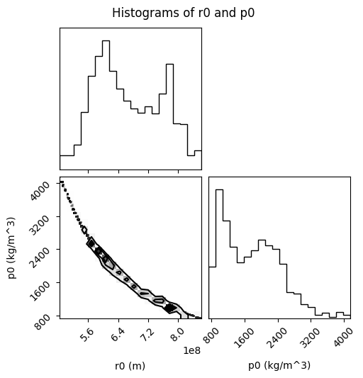

```python
fig = corner.corner(burned_in, labels=["r0 (m)", "p0 (kg/m^3)"])
fig.suptitle("Histograms of r0 and p0")
plt.show()
```

We can see the same close relationship between $r_0$ and $p_0$ in the KDE plot.

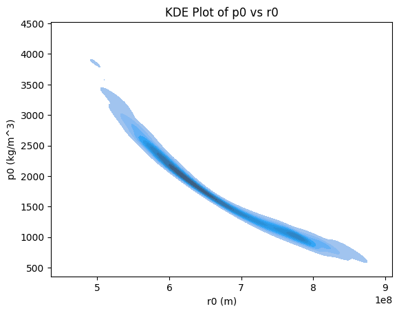

```python
xs = []
ys = []
for i in burned_in:
    xs.append(i[0])
    ys.append(i[1])

new_df = pd.DataFrame()
new_df['x'] = xs
new_df['y'] = ys

sbn.kdeplot(data=new_df, x=xs, y=ys, fill=True)
plt.xlabel('r0 (m)')
plt.ylabel('p0 (kg/m^3)')
plt.title("KDE Plot of p0 vs r0")
plt.show()
```

Finally, we plot the output of our model against the original data. To get a smoother curve, we generate 1000 points within the radius range of the planets, and we then calculate the velocity at those points based on 100 random parameter pairs from our model. We can see that even though $r_0$ and $p_0$ have a wide spread, the plotted models are almost all the same and all fit the data well.

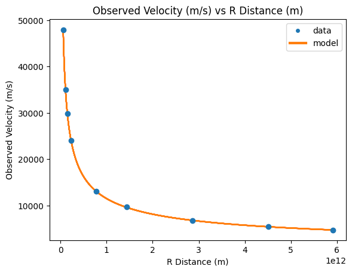

```python
distances = np.linspace(np.min(df.R_dist_m), np.max(df.R_dist_m), 1000)
legend_elements = [Line2D([0], [0], marker='o', color='white', markerfacecolor='C0', label='data'), Line2D([0], [0], color='C1', lw=3, label='model')]

for i in range(100):
    index = np.random.random_integers(0,30000)
    model = calc_velocity(burned_in[index], distances, density)
    plt.plot(distances, model, color = 'C1', alpha = 0.1)

plt.plot(df.R_dist_m, df.Vobs_m_per_s, 'o')
plt.xlabel("R Distance (m)")
plt.ylabel("Observed Velocity (m/s)")
plt.title("Observed Velocity (m/s) vs R Distance (m)")
plt.legend(handles=legend_elements)
plt.show()
```

### Part B: Galaxies with a Poor Model

For the next part of the problem, we will be focusing on galaxies. We read in the rotational speed information for the galaxy UGC 6787 and save it to rot_df. Similar to the last part, we first need to convert the units to meters. The radius distance is initially given in kiloparsecs while the observed velocity and velocity error are in km/s. We iterate through the rows of R_dist and convert them to meters using the conversion factor $3.0857\times19$ meters/kpc. We use the same function defined earlier to convert the km values to m. All of the new values are then added to the dataframe.

```python
rot_df = pd.read_csv("data/UGC06787_rot.csv", comment='#')
rot_d_in_m = []
for i in rot_df.R_dist:
    rot_d_in_m.append(i * 3.0857E19)
rot_df["R_dist_m"] = rot_d_in_m
rot_df["Vobs_m_per_s"] = km_convert_to_m(rot_df.Vobs)
rot_df["errV_m_per_s"] = km_convert_to_m(rot_df.errV)
```

The density and prior functions we use here are the same as the first part, so we did not redefine them. The likelihood function has been changed to use the distances and velocity information from the galaxy information. We redefine the posterior function to use the new likelihood.

```python
def ln_likelihood_b(params):
    model = calc_velocity(params, rot_df.R_dist_m, density)
    residual = rot_df.Vobs_m_per_s - model
    term1 = - 0.5 * np.log(2 * np.pi * rot_df.errV_m_per_s ** 2)
    term2 = - 0.5 * residual ** 2 / rot_df.errV_m_per_s**2
    return sum(term1 + term2)

def ln_pdf_b(params):
    p = ln_prior(params)
    if p == -np.inf:
        return -np.inf
    return p + ln_likelihood_b(params)
```

Once again, we create our MCMC chains, this time setting our starting parameters as $r_0=1\times10^20 m$ and $p_0=5\times10^{-20} kg/m^3$. The rest of the emcee EnsembleSampler is created the same as in the first part, and we ran it for 2000 iterations again.

```python
params_b = [1E20, 5E-20]
num_walkers_b = 20
sampler_b = emcee.EnsembleSampler(num_walkers_b, 2, ln_pdf_b)
starts_b = np.random.multivariate_normal(
            mean = params_b,
            cov = [[(params_b[0]/100)**2,0],[0,(params_b[1]/100)**2]],
            size = num_walkers_b
            )
out_b = sampler_b.run_mcmc(starts_b, 2000, progress=True)
```

We now plot the resulting trace plots of our parameters. We selected 500 iterations (shown in red on the plots below) as the burn-in point.

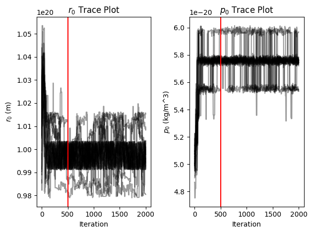

```python
fig, ax = plt.subplots(ncols=2)

ax[0].plot(sampler_b.get_chain()[:,:,0], 'k', alpha=0.4)
ax[0].axvline(x=500, ymin=0, ymax=1, color='red', label='burn-in point')
ax[0].set_xlabel("Iteration")
ax[0].set_ylabel("$r_0$ (m)")
ax[0].set_title("$r_0$ Trace Plot")

ax[1].plot(sampler_b.get_chain()[:,:,1], 'k', alpha=0.4)
ax[1].axvline(x=500, ymin=0, ymax=1, color='red', label='burn-in point')
ax[1].set_xlabel("Iteration")
ax[1].set_ylabel("$p_0$ (kg/m^3)")
ax[1].set_title("$p_0$ Trace Plot")

plt.tight_layout()
plt.show()
```

We can now cut out our burn-in and flatten all walkers into a singular chain for each parameter. We set our burn-in to 500 and use `get_chain()`, specifying `discard=burn_in` and `flat=True` once again.

```python
burn_in_b = 500
burned_in_b = sampler_b.get_chain(discard=burn_in_b, flat=True)
```

We again use the corner library to plot all 1D and 2D histogram combinations of the parameters. We can see that $r_0$ and $p_0$ have a much more discrete relationship based on this data. We can see a few areas of concentration on the 2D histogram but the relationship is not continuous.

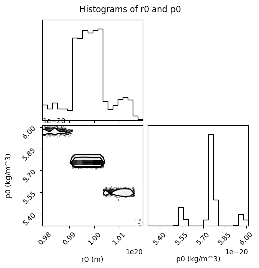

```python
fig = corner.corner(burned_in_b, labels=["r0 (m)", "p0 (kg/m^3)"])
fig.suptitle("Histograms of r0 and p0")
plt.show()
```

We can see the same relationship in the KDE plot.

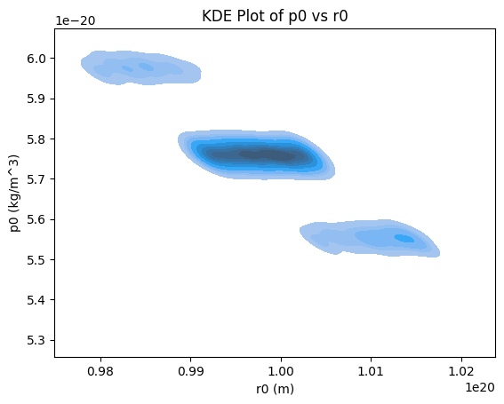

```python
xs_b = []
ys_b = []
for i in burned_in_b:
    xs_b.append(i[0])
    ys_b.append(i[1])

new_df_b = pd.DataFrame()
new_df_b['x'] = xs_b
new_df_b['y'] = ys_b

sbn.kdeplot(data=new_df_b, x=xs_b, y=ys_b, fill=True)
plt.xlabel('r0 (m)')
plt.ylabel('p0 (kg/m^3)')
plt.title("KDE Plot of p0 vs r0")
plt.show()
```

Finally, we plot the output of our model against the original data. To get a smoother curve, we generate 1000 points within the radius range of the galaxy, and we then calculate the velocity at those points based on 100 random parameter pairs from our model. Despite the variation in $r_0$ and $p_0$, the model outputs seem to be fairly consistent. However, they do not fit the data well at all.

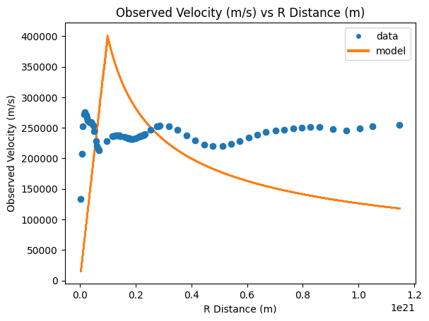

```python
distances_b = np.linspace(np.min(rot_df.R_dist_m), np.max(rot_df.R_dist_m), 1000)
legend_elements = [Line2D([0], [0], marker='o', color='white', markerfacecolor='C0', label='data'), Line2D([0], [0], color='C1', lw=3, label='model')]

for i in range(100):
    index = np.random.random_integers(0,5000)
    model = calc_velocity(burned_in_b[index], distances_b, density)
    plt.plot(distances_b, model, color = 'C1', alpha = 0.1)

plt.plot(rot_df.R_dist_m, rot_df.Vobs_m_per_s, 'o')
plt.xlabel("R Distance (m)")
plt.ylabel("Observed Velocity (m/s)")
plt.title("Observed Velocity (m/s) vs R Distance (m)")
plt.legend(handles=legend_elements)
plt.show()
```

### Part C: Galaxies with Dark Matter

Since the model from the last part fit so poorly, we want to consider the effect that dark matter might have on the galaxy velocities. Thus, we change our density function to include an extra factor. The previous density model was for the light matter ($\rho_{lm}$), and we add the density for the dark matter using the Burkert profile:
$$\rho_{dm}(r)=\frac{\rho_1}{(1+\frac{r}{r_1})(1+(\frac{r}{r_1})^2)}$$
This formula has the parameters $r_1$ and $p_1$, which means that we will now have 4 parameters including the $r_0$ and $p_0$ parameters for the light matter. The density function that we constructed with this formula returns the sum of the light matter and dark matter terms: $\rho_{tot}=\rho_{lm}+\rho_{dm}$.

```python
def density_c(params, distances):
    r0, p0, r1, p1 = params
    p_lm = np.where(distances < r0, p0, 0)
    p_dm = p1 / ((1+distances/r1)*(1+(distances/r1)**2))
    return p_lm + p_dm
```

We redefined the Prior function to check that all 4 parameters are positive.

```python
def ln_prior_c(params):
    r0, p0, r1, p1 = params
    if r0 < 0 or p0 < 0 or r1 < 0 or p1 < 0:
        return -np.inf
    return 0
```

The Likelihood is the same as the last part, although it now uses the new density function.

```python
def ln_likelihood_c(params):
    model = calc_velocity(params, rot_df.R_dist_m, density_c)
    residual = rot_df.Vobs_m_per_s - model
    term1 = - 0.5 * np.log(2 * np.pi * rot_df.errV_m_per_s ** 2)
    term2 = - 0.5 * residual ** 2 / rot_df.errV_m_per_s**2
    return sum(term1 + term2)
```

The Posterior function is changed to use the prior and likelihood written for this part.

```python
def ln_pdf_c(params):
    p = ln_prior_c(params)
    if p == -np.inf:
        return -np.inf
    return p + ln_likelihood_c(params)
```

Once again, we create our MCMC chains, this time setting our starting parameters as $r_0=2\times10^19 m$, $p_0=1\times10^{-18} kg/m^3$, $r_1=1.25\times10^20 m$, $p_0=2\times10^{-20} kg/m^3$. The rest of the emcee EnsembleSampler is created the same as in the first two parts, although the multivariate distribution the start values are selected from is 4 dimensions, and we still run it for 2000 iterations.

```python
params_c = [2E19, 1E-18, 1.25E20, 2E-20]
num_walkers_c = 20
sampler_c = emcee.EnsembleSampler(num_walkers_c, 4, ln_pdf_c)
starts_c = np.random.multivariate_normal(
            mean = params_c,
            cov = [[(params_c[0]/100)**2,0,0,0],[0,(params_c[1]/100)**2,0,0],[0,0,(params_c[2]/100)**2,0],[0,0,0,(params_c[3]/100)**2]],
            size = num_walkers_c
            )
out = sampler_c.run_mcmc(starts_c, 2000, progress=True)
```

We now plot the resulting trace plots of our parameters. The values seem to converge fairly quickly so we selected 250 iterations as the burn-in point (shown in red on the plots below).

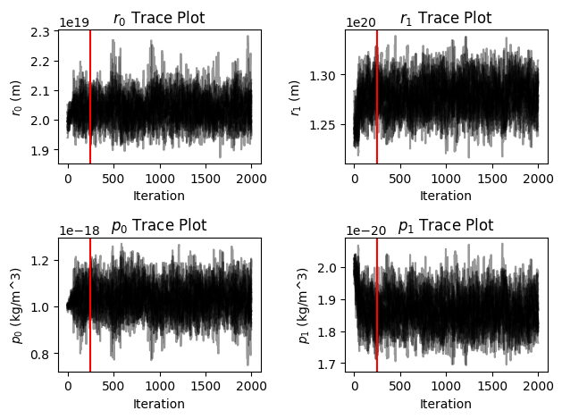

```python
fig, ax = plt.subplots(nrows=2, ncols=2)

ax[0,0].plot(sampler_c.get_chain()[:,:,0], 'k', alpha=0.4)
ax[0,0].axvline(x=250, ymin=0, ymax=1, color='red', label='burn-in point')
ax[0,0].set_xlabel("Iteration")
ax[0,0].set_ylabel("$r_0$ (m)")
ax[0,0].set_title("$r_0$ Trace Plot")

ax[1,0].plot(sampler_c.get_chain()[:,:,1], 'k', alpha=0.4)
ax[1,0].axvline(x=250, ymin=0, ymax=1, color='red', label='burn-in point')
ax[1,0].set_xlabel("Iteration")
ax[1,0].set_ylabel("$p_0$ (kg/m^3)")
ax[1,0].set_title("$p_0$ Trace Plot")

ax[0,1].plot(sampler_c.get_chain()[:,:,2], 'k', alpha=0.4)
ax[0,1].axvline(x=250, ymin=0, ymax=1, color='red', label='burn-in point')
ax[0,1].set_xlabel("Iteration")
ax[0,1].set_ylabel("$r_1$ (m)")
ax[0,1].set_title("$r_1$ Trace Plot")

ax[1,1].plot(sampler_c.get_chain()[:,:,3], 'k', alpha=0.4)
ax[1,1].axvline(x=250, ymin=0, ymax=1, color='red', label='burn-in point')
ax[1,1].set_xlabel("Iteration")
ax[1,1].set_ylabel("$p_1$ (kg/m^3)")
ax[1,1].set_title("$p_1$ Trace Plot")

plt.tight_layout()
plt.show()
```

We can now cut out our burn-in and flatten all walkers into a singular chain for each parameter. We set our burn-in to 250 and use `get_chain()` again, specifying `discard=burn_in` and `flat=True`.

```python
burn_in_c = 250
burned_in_c = sampler_c.get_chain(discard=burn_in_c, flat=True)
```

We again use the corner library to plot all 1D and 2D histogram combinations of the parameters. We can see that all parameters seem to have a peak and have explored the whole space. We also see that $r_0$ and $p_0$ seem to be related to each other and $r_1$ and $p_1$ also seem to be related to each other. This makes sense because the first two parameters are both in the light matter density portion and the second two are in the dark matter density portion, so they are more closely related within the densities than between them.

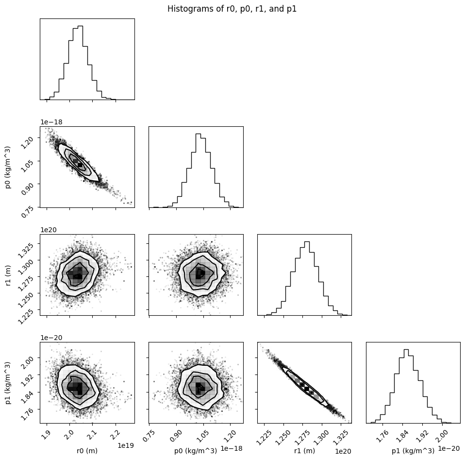

```python
fig = corner.corner(burned_in_c, labels=["r0 (m)", "p0 (kg/m^3)", "r1 (m)", "p1 (kg/m^3)"])
fig.suptitle("Histograms of r0, p0, r1, and p1")
plt.tight_layout()
plt.show()
```

Finally, we plot the output of our model against the original data. To get a smoother curve, we generate 1000 points within the radius range of the galaxy, and we then calculate the velocity at those points based on 100 random parameter pairs from our model. The model once again seems to be consistent between parameters, but this time, it more closely follows the data since the velocity levels out at greater distances.

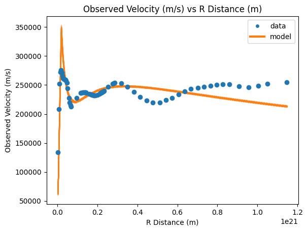

```python
distances_c = np.linspace(np.min(rot_df.R_dist_m), np.max(rot_df.R_dist_m), 1000)
legend_elements = [Line2D([0], [0], marker='o', color='white', markerfacecolor='C0', label='data'), Line2D([0], [0], color='C1', lw=3, label='model')]

for i in range(100):
    index = np.random.random_integers(0,35000)
    model = calc_velocity(burned_in_c[index], distances_c, density_c)
    plt.plot(distances_c, model, color = 'C1', alpha = 0.1)

plt.plot(rot_df.R_dist_m, rot_df.Vobs_m_per_s, 'o')
plt.xlabel("R Distance (m)")
plt.ylabel("Observed Velocity (m/s)")
plt.title("Observed Velocity (m/s) vs R Distance (m)")
plt.legend(handles=legend_elements)
plt.show()
```